# Seminar 04: RMarkdown

Jasper Hackling

06.05.2021

## Seminar 04: Learning RMarkdown

Hello everybody,

I am sure many of you already took the course “Data Analysis and Visualization” headed by Prof. Schoof. In that module, we were introduced to using the R programming language to analyse and visualise data for our research projects. Back then, my study group and I decided to hand in our assignments as PDF files created using RMarkdown, so we already came into contact with what Cory is teaching us right now.

For this week’s assignment in the decision analysis module, I thought “*Why not benefit from something I already did in the past?*”. Thus, I extracted some parts of our assignments from the last semester which I think looked especially nice in RMarkdown (Data Analysis and Visualization, Winter term 2020/21, Assignment 5). Please find them below and - if you like - tell me what you think. Hopefully some of you who are new to RMarkdown can find inspiration in these examples.

Additionally, here are some sources I found very helpful to get started with the RMarkdown basics, as well as some general tricks that I like personally:

- [RMarkdown Cheat Sheet](https://www.rstudio.com/wp-content/uploads/2015/02/rmarkdown-cheatsheet.pdf)
- [Official introductory lesson for using RMarkdown](https://rmarkdown.rstudio.com/lesson-1.html)
- To create a blank line in the output document (e.g. to separate paragraphs), just insert a backslash ("") followed by a blank space. The symbol shoud then change its colour to indicate that it’s read as a blank line.
- When creating PDFs, you might want to start a new paragraph on the top of a new page instead of on the bottom of the prior page. To do so, insert “” before the respective paragraph.
- Handy keyboard shortcuts:
  - Insert assignment arrow (<-): Alt + -
  - Insert pipe (%>%): Ctrl + Shift + M
  - Run current line: Shift + Enter
  - Insert code chunk in RMarkdown: Ctrl + Alt + I
  - [List of more keyboard shortcuts](https://www.rstudio.com/wp-content/uploads/2016/01/rstudio-IDE-cheatsheet.pdf)

Kind regards,  
Jasper

**Load necessary packages**

```r
library(ggplot2)
library(car)
```

### Exercise 1a

**Importing the data**

```r
tree_rings <- read.csv("tree_rings.csv")
tree_rings
```

**Describing the variables**

```r
str(tree_rings)
```

```
## 'data.frame':    32 obs. of  2 variables:
##  $ ring: num  0.5 1.5 1.7 0.8 1.6 1.5 1.2 1.2 0 0.9 ...
##  $ rain: int  184 284 264 284 304 304 244 224 204 264 ...
```

```r
class(tree_rings$ring)
```

```
## [1] "numeric"
```

```r
class(tree_rings$rain)
```

```
## [1] "integer"
```

#### Describing the values

**summary() function:**

```r
summary(tree_rings)
```

```
##       ring           rain
##  Min.   :0.00   Min.   :164.0
##  1st Qu.:1.05   1st Qu.:204.0
##  Median :1.35   Median :244.0
##  Mean   :1.15   Mean   :244.6
##  3rd Qu.:1.50   3rd Qu.:269.0
##  Max.   :1.70   Max.   :324.0
```

**Scatterplots:**

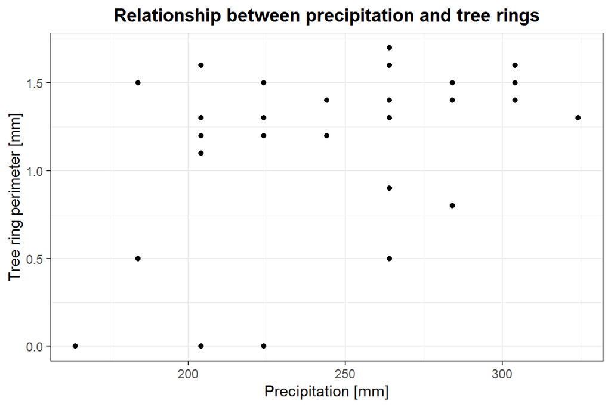

```r
ggplot(tree_rings, mapping = aes(x = rain, y = ring)) +
  geom_point() +
  labs(x = "Precipitation [mm]",
       y = "Tree ring perimeter [mm]",
       title = "Relationship between precipitation and tree rings") +
  theme_bw() +
  theme(plot.title = element_text(hjust = 0.5)) +   # Center title
  theme(plot.title = element_text(face = "bold"))   # Make title more visible
```

**Boxplot**

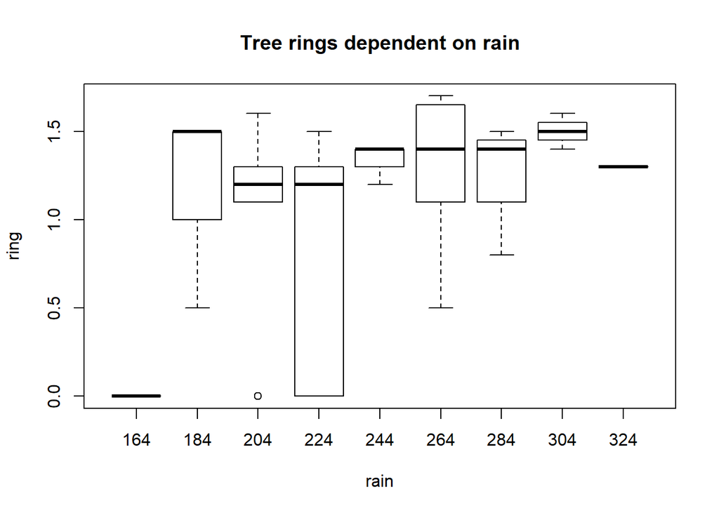

```r
attach(tree_rings)
boxplot(ring~rain,
        col = "white",  # Change box fill colour to white
        main = "Tree rings dependent on rain")  # Specify title
```

**Histograms:**

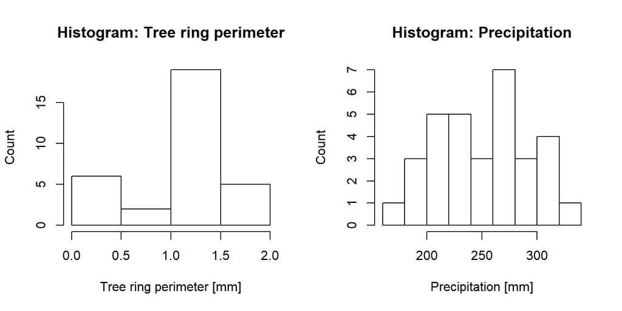

```r
par(mfrow = c(1,2))

hist(x = tree_rings$ring,
     xlab = "Tree ring perimeter [mm]",
     ylab = "Count",
     main = "Histogram: Tree ring perimeter",
     col = "white")

hist(x = tree_rings$rain,
     xlab = "Precipitation [mm]",
     ylab = "Count",
     main = "Histogram: Precipitation",
     col = "white")
```

**QQ-Plots:**

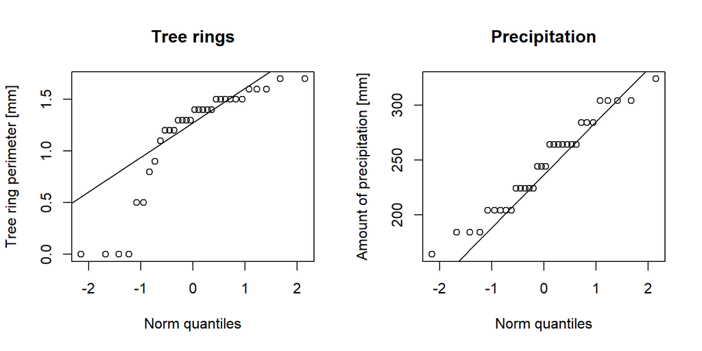

```r
par(mfrow = c(1,2))

# Variable "ring"
qqnorm(tree_rings$ring,
       xlab = "Norm quantiles",
       ylab = "Tree ring perimeter [mm]",
       main = "Tree rings")
qqline(tree_rings$ring)

# Variable "rain"
qqnorm(tree_rings$rain,
       xlab = "Norm quantiles",
       ylab = "Amount of precipitation [mm]",
       main = "Precipitation")
qqline(tree_rings$rain)
```

**Interpretation**

Deleting or keeping the outliers depends on what causes the outliers.They are most easy to identify when the dataset is portrayed as a boxplot or QQ-Plot. If the outliers are e.g. measuring mistakes, one should look at the QQ-Plot to identify the outliers and delete them from the dataset. If they are rare but part of the process one should keep them in the dataset. So with outliers one has to look at the individual case and decide what makes sense to do. They are most easy to identify when the dataset is portrayed as a boxplot or QQ-Plot. In this case, one outlier (on the 204 mm rain) can be identified based on the boxplot. The QQ-Plots underpin the results of the boxplot, revealing the same amount of outliers for the same amount of precipitation.

### Exercise 1b

First, we note that:

- Variable x (rain) = random effect
- Variable y (ring) = random effect

Accordingly, we deduce the following:

- Suitable correlation parameter: **Correlation coeffcient R** (Pearson)
- Appropriate regression model: **Model II** regression

### Exercise 1c

**Determining coefficient of correlation (R)**

```r
cor.test(tree_rings$rain, tree_rings$ring)
```

```
##
##  Pearson's product-moment correlation
##
## data:  tree_rings$rain and tree_rings$ring
## t = 2.341, df = 30, p-value = 0.02607
## alternative hypothesis: true correlation is not equal to 0
## 95 percent confidence interval:
##  0.05136486 0.65231764
## sample estimates:
##       cor
## 0.3930196
```

**Interpretation:**

The coeffcient of correlation between the “rain” and “ring” variable is **R = 0.39**. The closer R is to +1 or -1, the greater is the strength of the association. Therefore, the value at hand represents a positive yet rather weak correlation as it is smaller than 0.5.

### Exercise 1d

**Hypotheses:**

- $H_{0}$: p = 0
- $H_{A}$: p $\neq$ 0 (Population correlation unequal to zero $\Rightarrow$ linear correlation between both parameters on significance level $\alpha$ = 0.01)

```r
cor.test(x = tree_rings$rain,
         y = tree_rings$ring,
         conf.level = 0.99)
```

```
##
##  Pearson's product-moment correlation
##
## data:  tree_rings$rain and tree_rings$ring
## t = 2.341, df = 30, p-value = 0.02607
## alternative hypothesis: true correlation is not equal to 0
## 99 percent confidence interval:
##  -0.06287019  0.71320943
## sample estimates:
##       cor
## 0.3930196
```

**Interpretation**

$\varphi$ = 0.026 $>\alpha\Rightarrow$ keep $H_{0}$

As we cannot reject the $H_{0}$ hypothesis, we assume that there is **no significant linear correlation** between the two parameters on significance level $\alpha$ = 0.01.

### Exercise 2a

**Importing the data**

```r
Nplant <- read.delim("Nplant.txt", header = TRUE)
head(Nplant)
```

```
##   Nfertil pheight
## 1       5     7.4
## 2       5     6.5
## 3       5     8.0
## 4       5     7.6
## 5       5     7.3
## 6       8     8.3
```

**Establishing factor levels for categorical-scale fertiliser variable**

```r
# How many different fertiliser levels are there?
unique(Nplant$Nfertil)
```

```
## [1]  5  8 11 14 17
```

```r
# Create vector containing precipitation levels
fertil_levels <- unique(Nplant$Nfertil)

# Create new data frame with "Nfertil" variable as factor vector
Nplant_fac <- Nplant

# Introduce factor levels to "Nfertil" variable
Nplant_fac$Nfertil <- factor(Nplant_fac$Nfertil, levels = fertil_levels)

# Check for success
class(Nplant_fac$Nfertil)
```

```
## [1] "factor"
```

**Histogram**

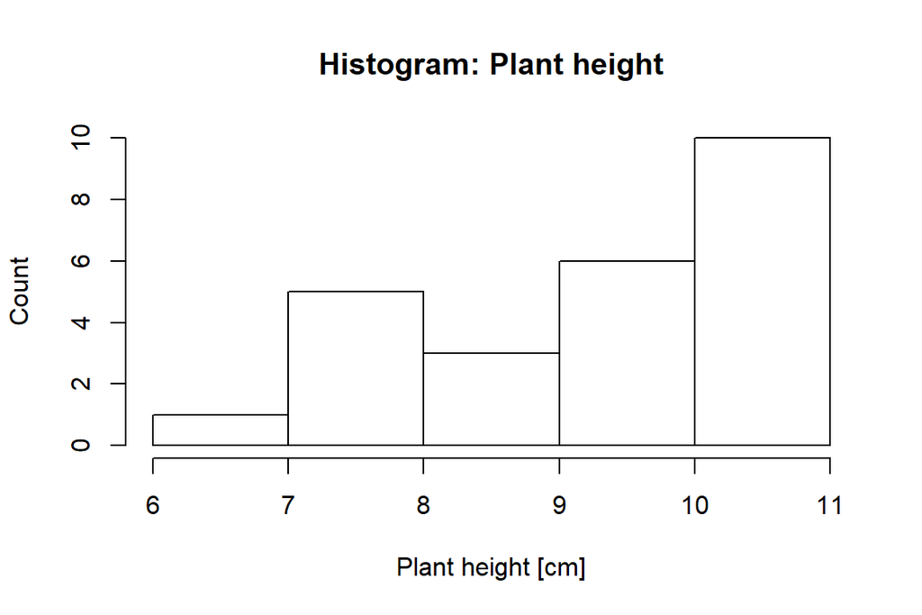

```r
hist(x = Nplant_fac$pheight,
     xlab = "Plant height [cm]",
     ylab = "Count",
     main = "Histogram: Plant height",
     col = "white")
```

**Scatterplot**

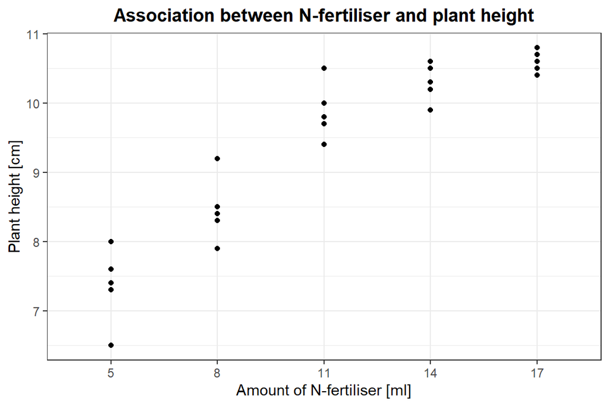

```r
ggplot(Nplant_fac, mapping = aes(x = Nfertil, y = pheight)) +
  geom_point() +
  labs(x = "Amount of N-fertiliser [ml]",
       y = "Plant height [cm]",
       title = "Association between N-fertiliser and plant height") +
  theme_bw() +
  theme(plot.title = element_text(hjust = 0.5)) +   # Center title
  theme(plot.title = element_text(face = "bold"))   # Make title more visible
```

**Boxplot**

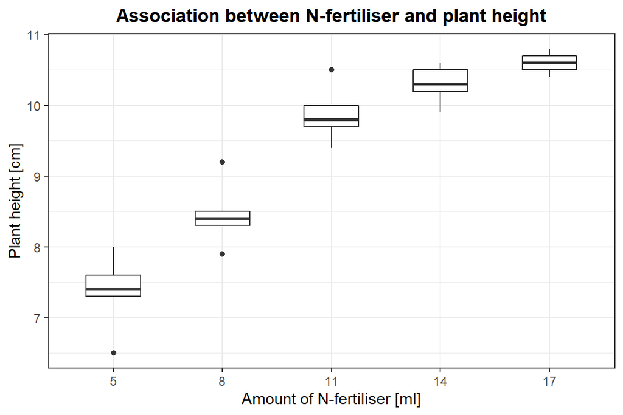

```r
ggplot(Nplant_fac)+
  geom_boxplot(mapping = aes(x = Nfertil, y = pheight),
               width = 0.5) +    # Change box width
  labs(x = "Amount of N-fertiliser [ml]",
       y = "Plant height [cm]",
       title = "Association between N-fertiliser and plant height") +
  theme_bw() +
  theme(plot.title = element_text(hjust = 0.5)) +
  theme(plot.title = element_text(face = "bold"))
```

Outliers can be identified on the 5, 8, and 11 ml factor levels.

**QQ-plots**

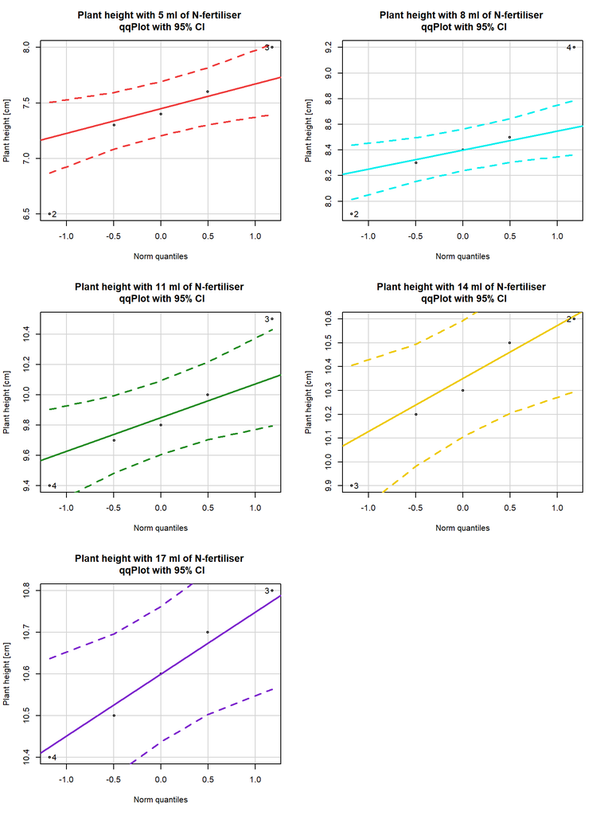

```r
par(mfrow = c(3,2))

qqPlot(subset(Nplant_fac, Nfertil == 5)$pheight,
       xlab = "Norm quantiles",
       ylab = "Plant height [cm]",
       main = "Plant height with 5 ml of N-fertiliser \n qqPlot with 95% CI",
       col.lines = "brown2")

qqPlot(subset(Nplant_fac, Nfertil == 8)$pheight,
       xlab = "Norm quantiles",
       ylab = "Plant height [cm]",
       main = "Plant height with 8 ml of N-fertiliser \n qqPlot with 95% CI",
       col.lines = "cyan2")

qqPlot(subset(Nplant_fac, Nfertil == 11)$pheight,
       xlab = "Norm quantiles",
       ylab = "Plant height [cm]",
       main = "Plant height with 11 ml of N-fertiliser \n qqPlot with 95% CI",
       col.lines = "forestgreen")

qqPlot(subset(Nplant_fac, Nfertil == 14)$pheight,
       xlab = "Norm quantiles",
       ylab = "Plant height [cm]",
       main = "Plant height with 14 ml of N-fertiliser \n qqPlot with 95% CI",
       col.lines = "gold2")

qqPlot(subset(Nplant_fac, Nfertil == 17)$pheight,
       xlab = "Norm quantiles",
       ylab = "Plant height [cm]",
       main = "Plant height with 17 ml of N-fertiliser \n qqPlot with 95% CI",
       col.lines = "purple3")
```

Just as with in boxplot depicted before, outliers can be identified on the 5, 8, and 11 ml factor levels.

**Interpretation**

Deleting or keeping the outliers depends on what causes the outliers.They are most easy to identify when the dataset is portrayed as a boxplot or QQ-Plot. If the outliers are e.g. measuring mistakes, one should look at the QQ-Plot to identify the outliers and delete them from the dataset. If they are rare but part of the process one should keep them in the dataset. So with outliers one has to look at the individual case and decide what makes sense to do. They are most easy to identify when the dataset is portrayed as a boxplot or QQ-Plot.

In this case, four outliers (one on the 5 ml, two on the 8 ml and one on the 11 ml factor level) can be identified based on the boxplot. The QQ-Plots underpin the results of the boxplot, revealing the same amount of outliers for the same levels of fertiliser.